# PCA, NMF, and Mixture Models

## PCA on Faces

Find the `pain.rda` file.

```r
load("pain.rda")
```

First, note the structure of the data

```r
dim(pain)
```

```
## [1] 241 181  84
```

With a bit of knowledge of the data, it’s clear this is an array where the first two dimensions make up the pixels and the third dimension indexes the different pictures. Let’s try out the image function!

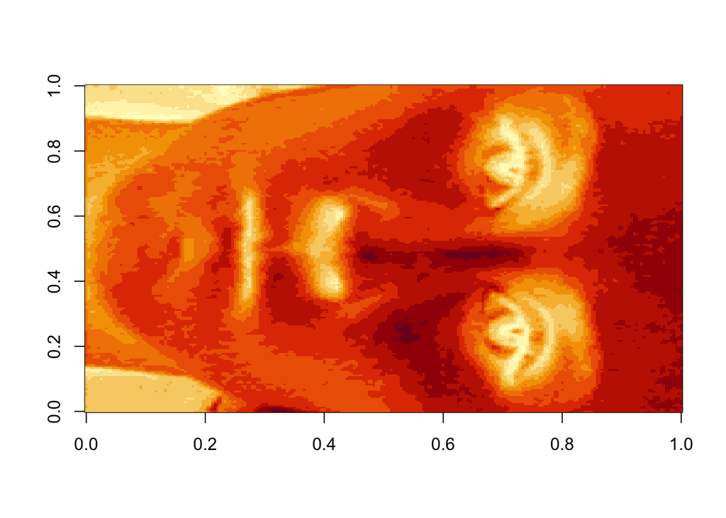

```r
image(pain[,,1])
```

Two problems. It’s obviously sideways, but I’m also not a big fan of the heatmap colour-scheme. Let’s fix both…

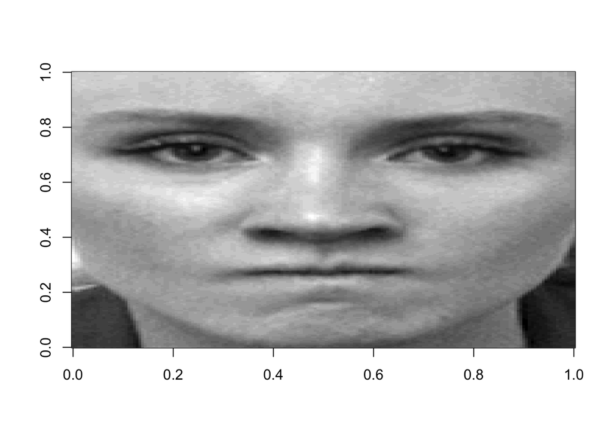

```r
image(t(pain[,,1]), col=gray((0:32)/32))
```

Much better, the following code can cycle you through all the pictures (3 a second)

```r
for(i in 1:84){
  image(t(pain[,,i]), col=gray((0:32)/32))
  Sys.sleep(1/3)
}
```

Alright, time to set this data up for analysis. We want each image flattened out as a vector

```r
flim <- apply(pain, 3, as.vector)
dim(flim)
```

```
## [1] 43621    84
```

dimensions aren’t quite what we’re used to (p x n)…so we’ll just transpose to make it (n x p).

```r
flim <- t(flim)
dim(flim)
```

```
## [1]    84 43621
```

Now to run PCA

```r
prface <- prcomp(flim, scale.=TRUE)
```

Let’s try to take a peak at the first eigenvector. Note that the eigenvectors are flattened images (as a vector instead of a matrix), so we need to think back to how it was flattened in the first place

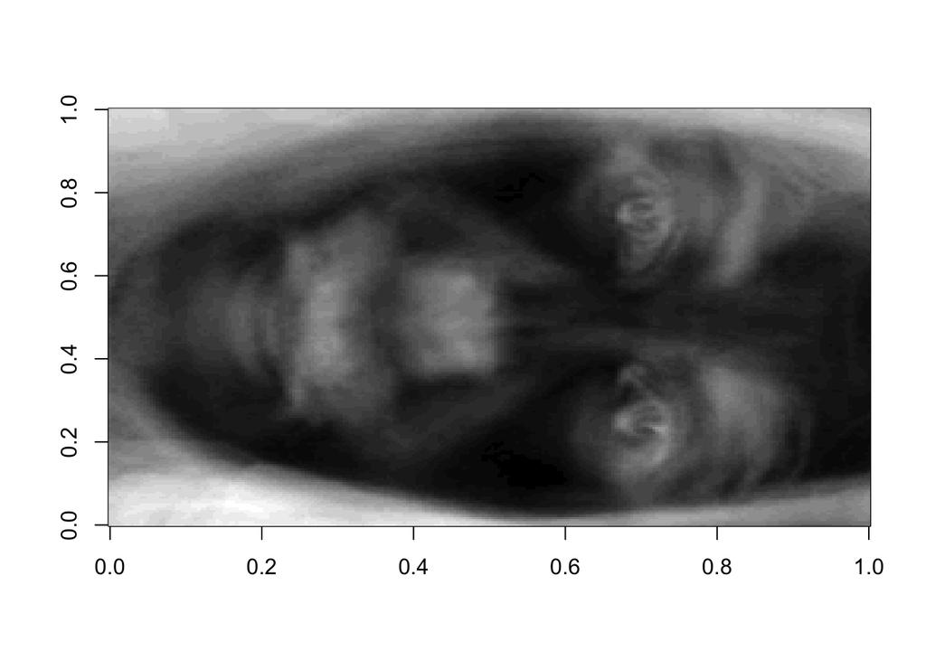

```r
image(matrix(prface$rotation[,1], 241, 181), col=gray((0:32)/32))
```

Looks like we guessed right for unflattening, but we need to transpose again

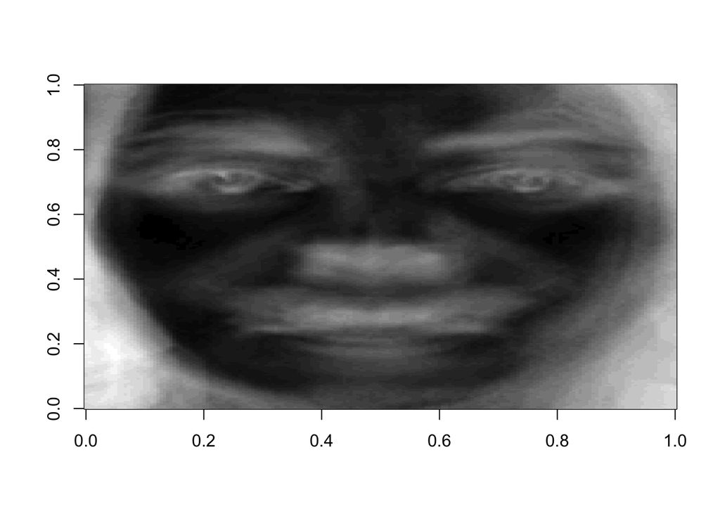

```r
image(t(matrix(prface$rotation[,1], 241, 181)), col=gray((0:32)/32))
```

Now let’s get the 16 eigenvectors in one plot. To do this, we will need to change around the device window settings. First part is to tell it to split the window into 4x4, and the next two parts will get rid of the majority of the margins

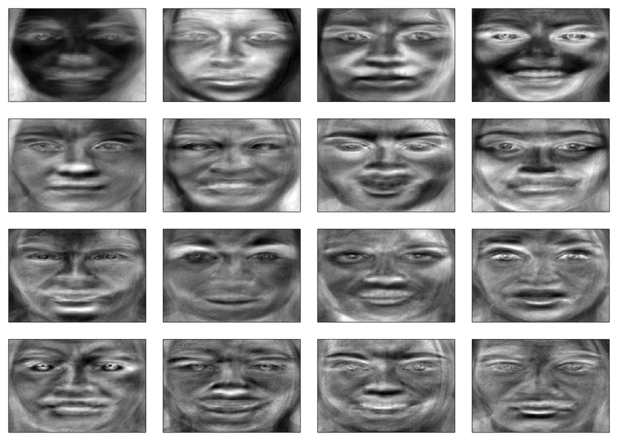

```r
par(mfrow=c(4,4), omi=c(0,0,0,0), mai=c(0.1,0.1,0.1,0.1))
for(i in 1:16){
  image(t(matrix(prface$rotation[,i], 241, 181)), col=gray((0:32)/32), xaxt="n", yaxt="n")
}
```

Again, we can walk through these pictures a bit. The first eigenvector seems to be mostly focused on picking up the background, nose, mouth, and eyebrows. The second brings in most the rest of the facial features, third cheeks, fourth eyes and chin, etc. It’s again noteworthy that images could score either negative or positive on these features. AKA, one could add lots of white from vector 2 for the face with a positive score, and then subtract vector 4 to set the eyes deeper with a negative score.

And what about that scaling we did, what’s the average face?

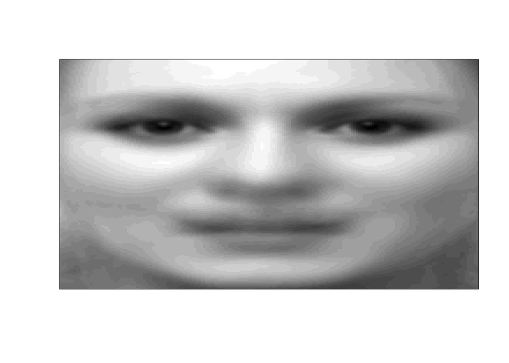

```r
par(mfrow=c(1,1))
image(t(matrix(prface$center, 241, 181)), col=gray((0:32)/32), xaxt="n", yaxt="n")
```

Now let’s go about reconstructing approximations of the original images with the PCs. First attempt: 10 PCs.

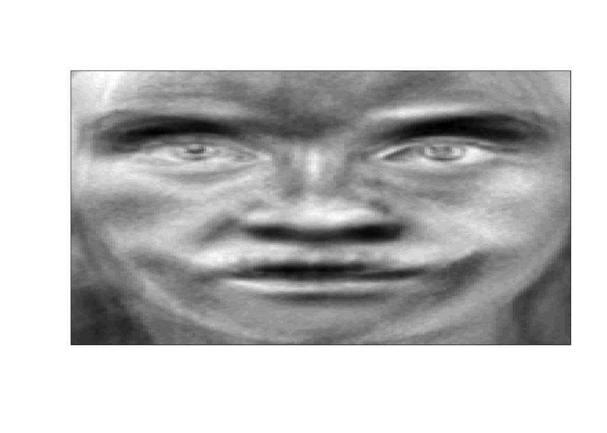

```r
i <- 10
reconst <- (t(prface$rotation[,1:i] %*% t(prface$x[,1:i])))
image(t(matrix(reconst[1,], 241, 181)), col=gray((0:32)/32), xaxt="n", yaxt="n")
```

This seems a little too negative looking. Well…we forgot about all that scaling! In order to reconstruct, we have to re-multiply by the standard deviation, and then re-add the mean. The easiest way to do this is to use the scale function again

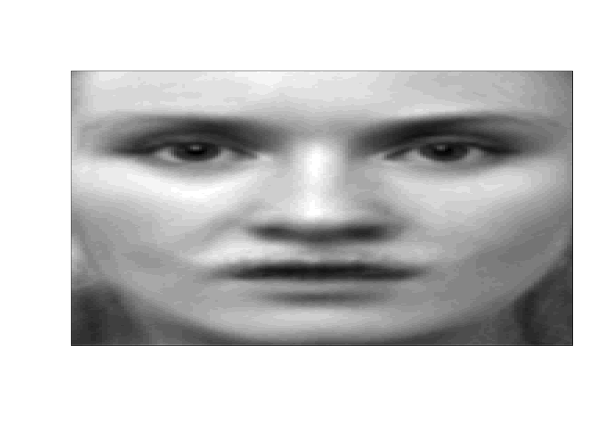

```r
reconst <- scale(reconst, center=FALSE, scale=1/prface$scale)
reconst <- scale(reconst, center=-prface$center, scale=FALSE)
image(t(matrix(reconst[1,], 241, 181)), col=gray((0:32)/32), xaxt="n", yaxt="n")
```

And compare to the original

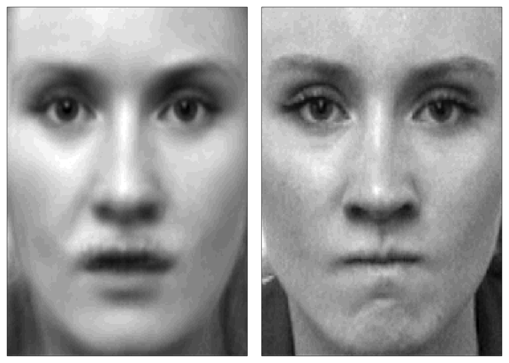

```r
par(mfrow=c(1,2), omi=c(0,0,0,0), mai=c(0.1,0.1,0.1,0.1))
image(t(matrix(reconst[1,], 241, 181)), col=gray((0:32)/32), xaxt="n", yaxt="n")
image(t(pain[,,1]), col=gray((0:32)/32), xaxt="n", yaxt="n")
```

Overall, not a terrible approximation. The general structure of the face looks pretty good, though the mouth could still use some work!

This will recreate the video of the approximations for 4 images while we iterate from using just one PC to using all 84 PCs. Again, `eval=FALSE` is a good idea for the markdown document. `Sys.sleep` may need to be played with for your system to generate everything in time.

```r
for(i in 1:84){
  reconst <- (t(prface$rotation[,1:i] %*% t(prface$x[,1:i])))
  reconst <- scale(reconst, center=FALSE, scale=1/prface$scale)
  reconst <- scale(reconst, center=-prface$center, scale=FALSE)
  par(mfrow=c(2,4), omi=c(0,0,0,0), mai=c(0.1,0.1,0.1,0.1))
  image(t(matrix(reconst[21,], 241, 181)), col=gray((0:32)/32), xaxt="n", yaxt="n")
  image(t(pain[,,21]), col=gray((0:32)/32), xaxt="n", yaxt="n")
  image(t(matrix(reconst[25,], 241, 181)), col=gray((0:32)/32), xaxt="n", yaxt="n")
  image(t(pain[,,25]), col=gray((0:32)/32), xaxt="n", yaxt="n")
  image(t(matrix(reconst[44,], 241, 181)), col=gray((0:32)/32), xaxt="n", yaxt="n")
  image(t(pain[,,44]), col=gray((0:32)/32), xaxt="n", yaxt="n")
  image(t(matrix(reconst[58,], 241, 181)), col=gray((0:32)/32), xaxt="n", yaxt="n")
  image(t(pain[,,58]), col=gray((0:32)/32), xaxt="n", yaxt="n")
  Sys.sleep(1/2)
}
```

## NMF

Now we will go through NMF.

```r
#x: the non-negative data (if any negatives exist, the whole data is shifted)
#q: the number of factors/bases
#eps: convergence criteria (lack of progress on sum squared error)
#maxit: convergence criteria (max iteration when lack of progress not met)
#w: n by q scores on factors
#h: q by p observed factors/bases
#By default (when w, h NULL) both w and h are initialized randomly
nmf <- function(x, q, eps=0.001, maxit=2000, w=NULL, h=NULL){
  n <- nrow(x)
  p <- ncol(x)
  if(any(x<0)){x <- as.matrix(x)+abs(min(x))}
  else{x <- as.matrix(x)}
  if(is.null(w)){
    w <- matrix(runif(n*q, min(x), max(x)), n, q)
  }
  if(is.null(h)){
    h <- matrix(runif(p*q, min(x), max(x)), q, p)
  }
  ed <- sum((x-w%*%h)^2)
  conv <- FALSE
  ctr <- 1
  while(!conv){
    ctr <- ctr+1
    h <- h * (t(w) %*% x) / (t(w) %*% w %*% h)
    w <- w * (x %*% t(h)) / (w %*% h %*% t(h))
    wh <- w%*%h
    ed[ctr] <- sum((x-wh)^2)
    if((ed[ctr-1]-ed[ctr] < eps)|(ctr==maxit)){
      conv <- TRUE
    }
  }
  list(ed=ed, w=w, h=h, x=x)
}
```

This takes about 3.5 mins to run, hence the `eval=FALSE`.

```r
set.seed(5213541)
test <- nmf(flim, 16, maxit=600)
image(t(matrix(test$h[2,], 241, 181)), col=gray((0:32)/32), xaxt="n", yaxt="n")
```

```r
par(mfrow=c(4,4), omi=c(0,0,0,0), mai=c(0.1,0.1,0.1,0.1))
for(i in 1:16){
  image(t(matrix(test$h[i,], 241, 181)), col=gray((0:32)/32), xaxt="n", yaxt="n")
}
```

We can look at reconstructions and compare with pca

```r
nmfrec <- test$w %*% test$h
par(mfrow=c(4,3), omi=c(0,0,0,0), mai=c(0.1,0.1,0.1,0.1))
image(t(matrix(reconst[21,], 241, 181)), col=gray((0:32)/32), xaxt="n", yaxt="n")
image(t(matrix(nmfrec[21,], 241, 181)), col=gray((0:32)/32), xaxt="n", yaxt="n")
image(t(pain[,,21]), col=gray((0:32)/32), xaxt="n", yaxt="n")
image(t(matrix(reconst[25,], 241, 181)), col=gray((0:32)/32), xaxt="n", yaxt="n")
image(t(matrix(nmfrec[25,], 241, 181)), col=gray((0:32)/32), xaxt="n", yaxt="n")
image(t(pain[,,25]), col=gray((0:32)/32), xaxt="n", yaxt="n")
image(t(matrix(reconst[44,], 241, 181)), col=gray((0:32)/32), xaxt="n", yaxt="n")
image(t(matrix(nmfrec[44,], 241, 181)), col=gray((0:32)/32), xaxt="n", yaxt="n")
image(t(pain[,,44]), col=gray((0:32)/32), xaxt="n", yaxt="n")
image(t(matrix(reconst[58,], 241, 181)), col=gray((0:32)/32), xaxt="n", yaxt="n")
image(t(matrix(nmfrec[58,], 241, 181)), col=gray((0:32)/32), xaxt="n", yaxt="n")
image(t(pain[,,58]), col=gray((0:32)/32), xaxt="n", yaxt="n")
```

## Mixture Models

Not a ton of context to provide here, just a quick demo of a couple of different mixture model options in R applied to a couple of data sets that we’re used to!

```r
library(mclust)
```

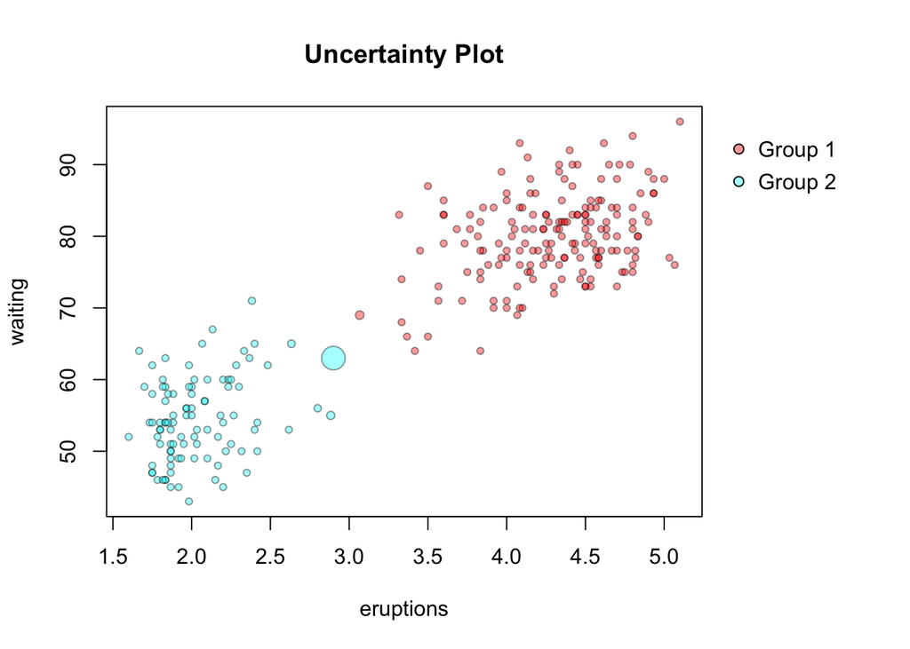

```r
mfaith <- Mclust(faithful, G=1:5)
library(teigen)
tfaith <- teigen(faithful, Gs=1:5, model="UUUU", scale=FALSE, verbose = FALSE)
plot(tfaith, what="uncertainty")
```

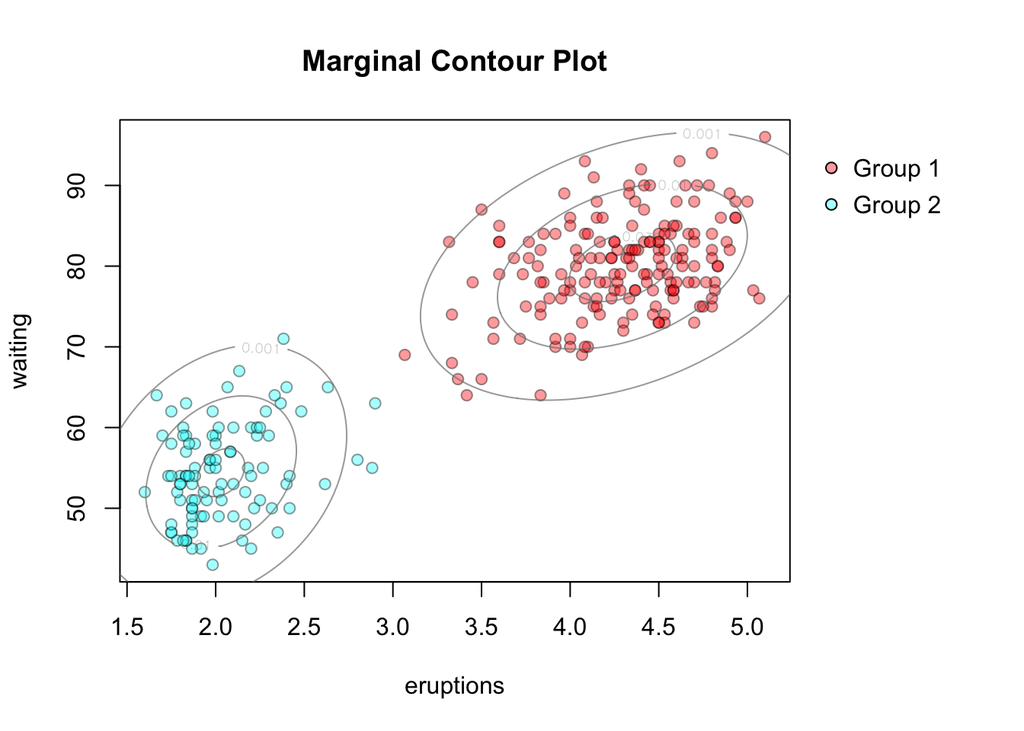

```r
plot(tfaith, what="contour")
```

```r
library(gclus)
```

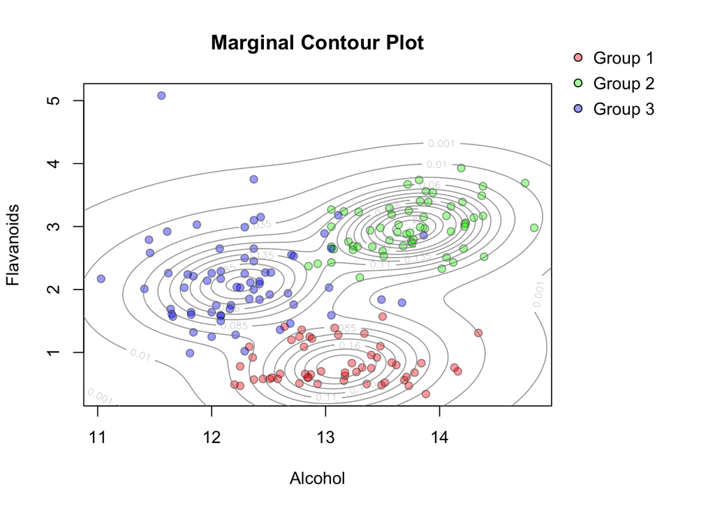

```r
data(wine)
twine <- teigen(wine[,-1], Gs=1:5, model="UCCU", scale=FALSE, verbose=FALSE)
plot(twine, xmarg=1, ymarg=7, what="contour")
```

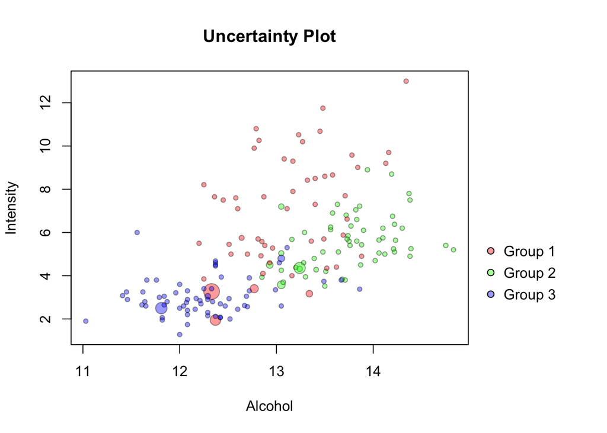

```r
plot(twine, xmarg=1, ymarg=10, what="uncertainty")
```

```r
table(wine[,1], twine$classification)
```

```
##
##      1  2  3
##   1  0 59  0
##   2  5  0 66
##   3 48  0  0
```

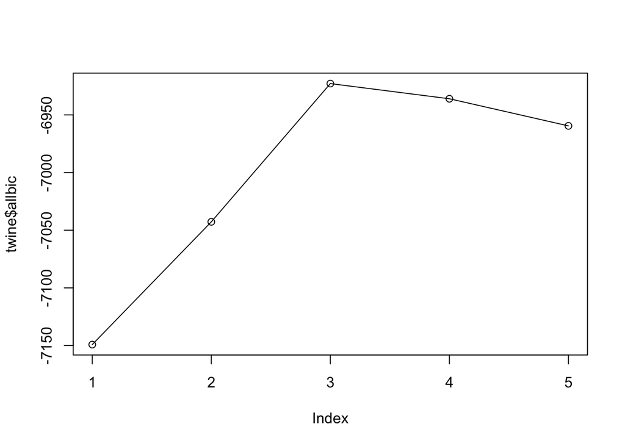

```r
plot(twine$allbic, type="l")
points(twine$allbic)
```